# **Detecting Malaria Parasites in Blood Smear Microscopy**

### A cross-framework CNN study from raw cell images to on-device Core ML

> By: **Arthur Nsereko Kahwa**

# Part 1 — Problem, Data & Preprocessing

> **What this part covers (beginner roadmap):**

> This first part of the project is the *foundation* — before any deep-learning model is built, we need to:
> 1. **State the problem** in plain language so anyone (including non-engineers) understands what we are trying to solve.
> 2. **Set up the environment** so the same notebook can run unchanged on Google Colab, Kaggle, or a local laptop.
> 3. **Load the data** (microscopy images of red blood cells) into NumPy arrays — the universal numerical format that every Python ML library understands.
> 4. **Preprocess** the data: resize every image to a uniform size, scale pixel values, and check for class balance.
> 5. **Explore** the data visually so we develop intuition about what the model will see.

> Only after all of that do we start training models in later parts. Skipping this groundwork is the most common reason ML projects fail — a clean, well-understood dataset is more important than any clever architecture.

## Problem Definition

> **Why we start here:** Every machine-learning project must begin by precisely defining (a) the *real-world question* being asked, (b) the *inputs* available to answer it, (c) the *outputs* the model must produce, and (d) the *measure of success*. Without those four pieces, you cannot tell when you are done — and you cannot tell whether a 95%-accurate model is actually good enough.

**The context:** Malaria is a life-threatening disease caused by the *Plasmodium* parasite, transmitted through infected mosquito bites. Manual examination of blood smear microscopy images is the gold-standard diagnostic method, but it is time-consuming, error-prone, and requires trained personnel. An automated deep-learning pipeline can deliver fast, consistent, and scalable diagnosis, particularly in resource-limited regions.

> **Beginner notes on the vocabulary above:**
> - **Plasmodium**: the genus of parasites that cause malaria. Several species infect humans (`P. falciparum` is the deadliest).
> - **Blood smear microscopy**: a thin layer of blood spread on a glass slide, stained, and inspected under a microscope. Infected red blood cells contain visible dark/purple "ring" structures.
> - **Gold-standard**: the most reliable existing diagnostic technique, used as the reference against which new methods are compared.
> - **Deep-learning pipeline**: an automated chain of steps — load image, preprocess, run through a neural network, output a label — that replaces the human microscope reader.
> - **Resource-limited regions**: places where trained microscopists or expensive hardware are scarce. A model that runs on a phone (the iOS export later in this project) directly addresses this need.

**The objectives:** Build a binary image classifier that accurately distinguishes parasitized (malaria-infected) from uninfected red blood cell images using Convolutional Neural Networks (CNNs).

> **What every term means:**
> - **Binary classifier**: a model whose output is one of exactly two classes. Here: `Parasitized` or `Uninfected`. (If we had multiple parasite species we would call it *multi-class*; if a cell could be both stages of disease at once we would call it *multi-label*.)
> - **Image classifier**: a model whose input is an image (a 2D grid of pixels with colour channels) and whose output is a class label.
> - **Convolutional Neural Network (CNN)**: a special kind of neural network designed for grid-shaped data like images. The "convolutional" part refers to small filters (like sliding stencils) that scan across the image looking for visual patterns — edges, blobs, textures, eventually whole shapes. CNNs are the workhorse of modern computer vision.

**Some key questions:**

- Can raw pixel data from cell microscopy images reliably distinguish infected from healthy cells?
- Which CNN architecture or training strategy achieves the best generalisation?
- Does image preprocessing (normalisation, HSV conversion, blurring) or augmentation measurably improve model performance?
- Which pre-trained model, if any, outperforms custom CNNs for this domain?

> **Beginner glossary for the questions above:**
> - **Raw pixel data**: the numbers stored in the image file — three values (red, green, blue) per pixel, each an integer 0–255. "Raw" means we have not extracted hand-crafted features such as cell roundness or stain intensity; we feed the pixels straight into the model.
> - **Generalisation**: how well a model performs on data it has *never seen during training*. A model that memorises the training set but fails on new images is said to *overfit* and has poor generalisation.
> - **Architecture**: the shape and arrangement of the layers in a neural network — how many convolutions, how many fully-connected layers, how many neurons each, and so on.
> - **Training strategy**: the choices made *while* training — learning rate, optimiser, regularisation, augmentation, and so on.
> - **Normalisation**: rescaling pixel values into a small range (typically 0–1 or -1–1). Explained in detail later when we divide by 255.
> - **HSV conversion**: changing colour representation from RGB (Red/Green/Blue) to HSV (Hue/Saturation/Value). HSV separates *what colour* something is from *how bright* it is, which sometimes makes stained features easier to detect.
> - **Blurring**: applying a smoothing filter (e.g. Gaussian blur) to suppress noise. Tested in later parts.
> - **Augmentation**: artificially expanding the training set by random rotations, flips, brightness shifts, etc. Explained when we use Keras' `ImageDataGenerator`.
> - **Pre-trained model**: a network whose weights were already learned on a huge external dataset (typically ImageNet). We re-use those weights instead of starting from scratch — a technique called *transfer learning*.

**The problem formulation:** A supervised binary classification problem. Input: RGB microscopy images of individual red blood cells. Output: class label — `Parasitized` (1) or `Uninfected` (0). Performance is measured by accuracy, precision, recall, and F1-score on a held-out test set of 2,600 images.

> **Decoding the formal problem statement:**
> - **Supervised**: every training image comes with a *correct label* attached. The model learns by being shown an image, making a guess, comparing the guess to the true label, and adjusting its internal weights to reduce future error.
> - **Held-out test set**: a slice of the data that the model is *never* trained on, kept aside purely for honest evaluation. If we measured accuracy on the training set, the model could trivially memorise it and look perfect while still failing on real-world cells.
> - The four metrics (**accuracy, precision, recall, F1**) are defined in the next cell. We need *all four* because in medicine, missing a sick patient (false negative) is far worse than a false alarm (false positive), and a single number like "accuracy" cannot capture that asymmetry.

**Metric glossary** — terms used throughout the document:

| Metric | Formula | What it measures |
| --- | --- | --- |
| **Accuracy** | `(TP + TN) / total` | Fraction of all images classified correctly |
| **Precision** | `TP / (TP + FP)` | When the model predicts "Parasitized", how often is it right? |
| **Recall** (a.k.a. *sensitivity*) | `TP / (TP + FN)` | Of all actually-parasitized cells, how many did the model catch? |
| **F1-score** | `2·(precision·recall) / (precision+recall)` | Harmonic mean of precision and recall — a single number balancing the two |
| **Support** | (count) | The number of samples in a class (used as a table column, not a rate) |

> **Plain-English intuition for each metric:**
> - **Accuracy** answers "out of every 100 images, how many did I label correctly?" It is misleading on imbalanced datasets — if 99% of cells are uninfected, a model that always predicts "uninfected" scores 99% accuracy while being clinically useless.
> - **Precision** answers "when I cry wolf, is there a wolf?" High precision means few false alarms. Low precision wastes follow-up resources.
> - **Recall** answers "did I catch every wolf?" High recall means few missed cases. In medical screening, **recall is usually the metric you cannot compromise on** — a missed parasite means an untreated patient.
> - **F1-score** is the *harmonic mean* (a special average that punishes extremes) of precision and recall. It is useful when you need a single number but care about both kinds of error.
> - **Support** simply tells you how many real samples are in each class — useful context, not a quality measure.

Where **TP** = True Positives (correctly flagged parasitized), **FP** = False Positives (wrongly flagged parasitized), **TN** = True Negatives (correctly flagged uninfected), **FN** = False Negatives (missed parasitized cells — the clinically dangerous error). These four cells form the *confusion matrix* — a 2×2 table visualised under each model below.

> Every prediction the model makes lands in exactly one of these four cells. Looking at the *distribution* across cells tells you not just how often the model is wrong, but *which kind of mistake* it makes most. We render this as a heatmap (using seaborn) for every model in later parts.

## Setup

> **What "setup" means here:**

> Before any data work begins we install (or import) the libraries we will need, detect whether the notebook is running on a laptop / Colab / Kaggle, mount the user's Google Drive if applicable, locate and unzip the dataset, and fix random seeds so results are reproducible. Treat this as the foundation: every later section assumes these cells have already been executed in order from top to bottom.

### Imports and `say()` Helper

This is the **first cell to run** in every session. It imports `display` and `Markdown`, then defines `say()` — a thin wrapper that renders any string as formatted Markdown output directly beneath the calling cell. Every subsequent cell uses `say()` instead of the longer `display(Markdown(f\"\"\"...\"\"\"))` pattern. `say()` calls `display(Markdown(text))` internally — the import stays in this one cell only.

> **Why a custom helper?**

> Throughout this notebook we want results to appear as nicely-formatted Markdown tables, headings, and bold text — not raw `print()` output. Calling `display(Markdown(...))` every single time is verbose. Defining `say(this=...)` once cuts every later call down to a single readable line. The keyword-argument style (`say(this=f"...")`) reads almost like English: *say this*.

```python
# ─────────────────────────────────────────────────────────────────────────────
# Cell purpose: define the `say()` helper used by every other cell to display
# rich Markdown output (tables, headings, bold, inline code, LaTeX) directly
# inside the notebook.
# Inputs : none.
# Outputs: a global function `say(this=...)` that any later cell can call.
# Gotcha : this MUST be the first cell executed in any fresh kernel session.
#          If you run a later cell first, you will get a `NameError: name 'say'
#          is not defined`.
# ─────────────────────────────────────────────────────────────────────────────

# ── Must be the first cell executed ─────────────────────────────────────────
# The `say()` helper lets every subsequent cell render rich Markdown output
# (headings, tables, bold, inline code, LaTeX) without repeating the
# display(Markdown(...)) incantation every time. The `import` lines only
# appear here; every other cell assumes `say` is already in scope.
from IPython.display import display, Markdown  # display renders rich output; Markdown wraps a string so IPython treats it as formatted
# ↑ `display` is the function Jupyter uses internally to push any object into a cell's
#   output area. `Markdown(...)` wraps a plain string in an object whose rendering
#   rule is "interpret me as Markdown syntax". Together: take a string, treat it
#   as Markdown, render it under the cell.

def say(this: str) -> None:
    """Render *this* as formatted Markdown output below the current cell.

    Parameters
    ----------
    this : str
        A plain or f-string that may contain Markdown syntax, tables,
        bold/italic text, inline code, and LaTeX.

    Examples
    --------
    say(this=f"**Done** ✅")

    say(this=f'''
    | Metric | Value |
    |--------|-------|
    | Accuracy | `{acc:.4f}` |
    ''')
    """
    # Single line of implementation — the display() call emits the Markdown
    # object into the notebook's rich output area, where Jupyter/Colab renders it.
    display(Markdown(this))
    # Why a function and not a one-liner? Because it gives every later cell a
    # single, named, self-documenting verb (`say`) instead of a cryptic
    # `display(Markdown(...))` call. Less typing, easier to read, easier to
    # change globally if we ever want to redirect output (e.g. log to a file).
```

### Environment Detection

This cell detects where the notebook is running and configures paths, drive mounting, and hardware accordingly. It runs silently — nothing below needs to be changed manually when switching between environments.

> **Why bother detecting the environment?**

> The same `.ipynb` file is intended to run on (a) Google Colab, (b) Kaggle Kernels, and (c) a local machine. Each platform stores datasets in a different place — Colab inside `/content/drive/MyDrive`, Kaggle inside `/kaggle/input`, locally inside the user's working directory. Detecting the platform once at the top means later cells can build paths automatically, rather than forcing you to hand-edit a path constant every time you switch laptops or open Colab.

```python
# ─────────────────────────────────────────────────────────────────────────────
# Cell purpose: figure out *where* this notebook is running (Colab / Kaggle /
# local) and expose three boolean flags — IS_COLAB, IS_KAGGLE, IS_LOCAL — that
# every later setup cell branches on.
# Inputs : none (probes the runtime).
# Outputs: globals IS_COLAB, IS_KAGGLE, IS_LOCAL plus a Markdown summary table.
# Gotcha : the flags are computed once. If you somehow change environment
#          mid-session (you usually cannot), restart the kernel and re-run.
# ─────────────────────────────────────────────────────────────────────────────

# Standard-library modules — available everywhere without installation.
#   os       → filesystem operations (path joining, existence checks, etc.)
#   sys      → Python runtime info (version string, module registry)
#   platform → operating-system identification (Linux/macOS/Windows)
import os, sys, platform
# ↑ Standard library = ships with Python itself, no `pip install` needed.

# ── 1. Detect runtime environment ────────────────────────────────────────────
# Different environments store files in different places (Colab mounts Drive;
# Kaggle exposes datasets at /kaggle/input; local machines use the home or
# working directory). Every downstream path-building decision depends on
# knowing which one we're in, so we establish that first.

def in_colab():
    # The `google.colab` module only exists when Python is running inside a
    # Google Colab notebook. We don't actually USE the module — the import
    # itself is the probe. `noqa: F401` tells linters "yes I know it's unused".
    try:
        import google.colab          # noqa: F401
        return True
    except ImportError:
        # Import fails on any non-Colab environment → not Colab.
        return False
    # Why try/except instead of checking a path? Because Colab keeps changing
    # its filesystem layout, but the proprietary `google.colab` package has
    # been stable for years.

def in_kaggle():
    # Kaggle kernels always have /kaggle/input mounted — checking for it is
    # faster and more reliable than attempting a kaggle-specific import.
    return os.path.exists('/kaggle/input')
    # `os.path.exists` returns True for any file or directory at that path.

# Three booleans that together uniquely identify the runtime.
# ALL_CAPS is Python's convention for "constants" — values set once, never mutated.
IS_COLAB  = in_colab()
IS_KAGGLE = in_kaggle()
IS_LOCAL  = not IS_COLAB and not IS_KAGGLE   # "local" = neither of the two cloud environments
# ↑ Logical NOT/AND. If neither cloud probe succeeded, we must be running on
#   the user's own machine (laptop, workstation, server, etc.).

# Render a summary table so the reader can visually confirm where the notebook
# is running before any cells that depend on environment-specific paths run.
say(this=f"""
**Runtime environment:**

| Check | Value |
|-------|-------|
| Google Colab  | `{IS_COLAB}` |
| Kaggle        | `{IS_KAGGLE}` |
| Local / other | `{IS_LOCAL}` |
| Python        | `{sys.version.split()[0]}` |
| Platform      | `{platform.platform()}` |
""")
# ↑ f-string (formatted string literal) — any expression inside { } is
#   evaluated and inserted into the resulting string. `sys.version` looks like
#   "3.11.5 (main, ... )"; `.split()[0]` keeps just the "3.11.5" part.
```

**Runtime environment:**

| Check | Value |
| --- | --- |
| Google Colab | `False` |
| Kaggle | `False` |
| Local / other | `True` |
| Python | `3.11.9` |
| Platform | `macOS-26.4.1-arm64-arm-64bit` |

### Mount Drive *(Colab only)*

Only executed when running in Google Colab. On a local machine or Kaggle the cell resolves to a no-op.

> **What "mounting Drive" means:** Colab runs in a temporary virtual machine that disappears when the session ends. Mounting your Google Drive grafts your personal cloud storage onto the VM's filesystem at `/content/drive/MyDrive`, so you can read your dataset there as if it were a local folder. On Kaggle and on your own laptop there is no Drive to mount, so the cell falls through to a `getcwd()` (current working directory) fallback.

```python
# ─────────────────────────────────────────────────────────────────────────────
# Cell purpose: when running on Colab, mount the user's Google Drive so the
# dataset zip stored there becomes readable. On Kaggle and local, just record
# the current directory as the dataset root.
# Inputs : IS_COLAB (set in the previous cell).
# Outputs: global DRIVE_ROOT — the base directory used by later cells when
#          searching for `cell_images.zip`.
# Gotcha : on Colab the first run pops up a Google sign-in screen. Allow access
#          to your Drive; subsequent runs cache the credential.
# ─────────────────────────────────────────────────────────────────────────────

if IS_COLAB:
    # Colab-only: mount the user's Google Drive so the notebook can read
    # datasets stored there. The mount call pops up an authorisation prompt
    # on first run; subsequent runs use the cached token.
    from google.colab import drive
    drive.mount('/content/drive/Capstone Project')
    # ↑ The path argument is the *mount point* — where Colab grafts your Drive
    #   onto its filesystem. After this call your Drive contents are visible
    #   under that path.
    # After mounting, the user's Drive root appears at this path.
    DRIVE_ROOT = '/content/drive/MyDrive'
    # ↑ `MyDrive` is Drive's standard top-level folder name; everything you see
    #   when you open drive.google.com lives under it.
    say(this="✅ **Google Drive mounted** at `/content/drive/MyDrive`")
else:
    # Local or Kaggle: no Drive to mount. Use the notebook's current working
    # directory as the base path. This is the folder Jupyter was launched from.
    DRIVE_ROOT = os.getcwd()
    # ↑ os.getcwd() = "get current working directory". Equivalent to the
    #   command-line `pwd`. Whatever folder you launched Jupyter from is
    #   what you get back.
    say(this=f"ℹ️ **Not Colab** — using current working directory: `{DRIVE_ROOT}`")
```

ℹ️ **Not Colab** — using current working directory: `/Volumes/E3BB8868AC9/Users/arthur/Developer/aaidsp/Capstone_Project`

### Locate and Unzip the Dataset

The dataset is expected as a single zip file (`cell_images.zip`). The cell searches for it in the most common locations across environments and unzips it exactly once — re-running the notebook will not re-extract if the folder already exists.

> **What is in the zip?** The archive (originally published by the U.S. National Institutes of Health) contains 27,558 PNG images of red blood cells split into a `train/` and `test/` folder, each with two sub-folders `Parasitized/` and `Uninfected/`. We expect the layout to be:

> ```
> cell_images/
> ├── train/
> │   ├── Parasitized/
> │   └── Uninfected/
> └── test/
>     ├── Parasitized/
>     └── Uninfected/
> ```

> If the unzip produces a different layout the cell raises a clear error so you can fix it before later cells silently fail.

```python
# ─────────────────────────────────────────────────────────────────────────────
# Cell purpose: locate `cell_images.zip` in any of the standard places, extract
# it once into the appropriate writable folder, verify the resulting structure,
# and produce a summary table of how many images live in each split/class.
# Inputs : DRIVE_ROOT, IS_COLAB, IS_KAGGLE (set earlier).
# Outputs: globals ZIP_PATH, EXTRACT_DIR, DATASET_ROOT, TRAIN_DIR, TEST_DIR.
#          A Markdown summary listing the extracted file counts.
# Gotcha : if the zip is missing in every candidate location, the cell raises
#          FileNotFoundError. Re-running once the data is in place succeeds.
# ─────────────────────────────────────────────────────────────────────────────

# zipfile → built-in library for reading .zip archives
# shutil  → high-level file operations (currently unused but useful for cleanup)
import zipfile, shutil

# ── Search for the zip in environment-appropriate locations ──────────────────
# Rather than hard-coding one path, we try every plausible location and take
# the first that exists. This lets the same notebook run unchanged on Colab,
# Kaggle, or a local machine.
ZIP_CANDIDATES = [
    os.path.join(DRIVE_ROOT, 'cell_images.zip'),      # Colab: Google Drive (user uploaded there)
    '/content/cell_images.zip',                        # Colab: uploaded directly into the session
    '/kaggle/input/malaria-cell-images/cell_images.zip',  # Kaggle: dataset attached to the notebook
    os.path.join(os.getcwd(), 'cell_images.zip'),      # Local: same folder as the notebook
    os.path.expanduser('~/Downloads/cell_images.zip'), # Local: standard Downloads folder
]
# ↑ The list is ordered from most to least likely. `os.path.expanduser('~')`
#   expands `~` to the user's home directory in a cross-platform way.

# `next((expr for x in seq if cond), default)` is a generator-expression idiom:
# it iterates the list lazily and returns the FIRST element for which os.path.exists
# is true. If none exist, the default `None` is returned.
ZIP_PATH = next((p for p in ZIP_CANDIDATES if os.path.exists(p)), None)
# ↑ "Lazily" means we only check candidates one by one until we find a hit;
#   we do not scan the whole list if the first candidate is already there.

# Fail loudly with a clear explanation rather than proceeding with a broken path.
if ZIP_PATH is None:
    raise FileNotFoundError(
        "cell_images.zip not found. "
        "Upload it to Google Drive (Colab), the current directory (local), "
        "or /kaggle/input (Kaggle)."
    )
    # ↑ Failing fast (with a helpful message) is much better than letting the
    #   notebook crash 50 cells later when load_images() tries to read from
    #   a path that does not exist.
```

```python
# ── Extract destination ───────────────────────────────────────────────────────
# Each environment has a canonical writable folder. We unzip there rather than
# into the zip's own directory so the original archive stays untouched.
if IS_COLAB:
    EXTRACT_DIR = '/content'          # Colab's VM working directory, wiped between sessions
elif IS_KAGGLE:
    EXTRACT_DIR = '/kaggle/working'   # Kaggle's writable output folder
else:
    EXTRACT_DIR = os.getcwd()         # Local: just where we already are

# Three path constants used throughout the notebook. Using os.path.join rather
# than string concatenation with '/' keeps things portable across Windows / Unix.
DATASET_ROOT = os.path.join(EXTRACT_DIR, 'cell_images')
TRAIN_DIR    = os.path.join(DATASET_ROOT, 'train')
TEST_DIR     = os.path.join(DATASET_ROOT, 'test')
# ↑ These names are referenced by *every* later data-loading cell. Defining
#   them once means changing the layout (e.g. renaming `train` to `training`)
#   only requires editing this single block.
```

```python
# ── Unzip only if not already extracted ──────────────────────────────────────
# Re-running the notebook is a frequent operation — this guard avoids a
# 30-second re-extraction every time the cell fires.
if os.path.isdir(DATASET_ROOT):
    say(this=f"ℹ️ **Dataset already extracted** at `{DATASET_ROOT}` — skipping unzip.")
else:
    say(this=f"📦 **Extracting** `{ZIP_PATH}` → `{EXTRACT_DIR}` ...")
    # `with` guarantees the zip file is closed when the block exits, even if
    # an error is raised mid-extraction.
    with zipfile.ZipFile(ZIP_PATH, 'r') as zf:
        zf.extractall(EXTRACT_DIR)
        # ↑ Recursively extracts everything in the archive into EXTRACT_DIR,
        #   preserving the internal folder structure.
    say(this=f"✅ **Extraction complete.**")
```

📦 **Extracting** `/Volumes/E3BB8868AC9/Users/arthur/Developer/aaidsp/Capstone_Project/cell_images.zip` → `/Volumes/E3BB8868AC9/Users/arthur/Developer/aaidsp/Capstone_Project` ...

✅ **Extraction complete.**

```python
# ── Verify folder structure ───────────────────────────────────────────────────
# Catch the common failure mode: the zip unpacked into an unexpected layout
# (e.g. everything under one extra folder layer). Fail fast rather than having
# load_images() return empty arrays 200 lines later.
for split_dir in [TRAIN_DIR, TEST_DIR]:
    if not os.path.isdir(split_dir):
        raise FileNotFoundError(
            f"Expected folder not found after extraction: {split_dir}\n"
            "Check that the zip contains cell_images/train/ and cell_images/test/."
        )
```

```python
# Count images per split/class — produces a summary table showing the user
# exactly what was unzipped before anything downstream tries to load it.
summary_rows = ""
total = 0
for split in ['train', 'test']:
    for cls in sorted(os.listdir(os.path.join(DATASET_ROOT, split))):
        cls_dir = os.path.join(DATASET_ROOT, split, cls)
        if os.path.isdir(cls_dir):
            n = sum(1 for f in os.listdir(cls_dir)
                    if f.lower().endswith(('.png', '.jpg', '.jpeg')))
            # ↑ Generator expression inside `sum()` — counts files whose
            #   lowercase name ends with any of the listed extensions. Cheap
            #   way to count items matching a condition without building a list.
            total += n
            summary_rows += f"| {split} | {cls} | {n:,} |\n"
            # ↑ `{n:,}` formats integers with thousand-separators, e.g. 12,582.
```

```python
say(this=f"""
**Dataset contents after extraction:**

| Split | Class | Images |
|-------|-------|--------|
{summary_rows}
| **Total** | | **{total:,}** |

- Train directory: `{TRAIN_DIR}`
- Test directory:  `{TEST_DIR}`
""")
```

**Dataset contents after extraction:**

| Split | Class | Images |
| --- | --- | --- |
| train | parasitized | 12,582 |
| train | uninfected | 12,376 |
| test | parasitized | 1,300 |
| test | uninfected | 1,300 |

| **Total** | | **27,558** |

- Train directory: `/Volumes/E3BB8868AC9/Users/arthur/Developer/aaidsp/Capstone_Project/cell_images/train`

- Test directory: `/Volumes/E3BB8868AC9/Users/arthur/Developer/aaidsp/Capstone_Project/cell_images/test`

```python
# ─────────────────────────────────────────────────────────────────────────────
# Cell purpose: pretty-print the on-disk folder layout as a small ASCII tree
# so the reader can visually confirm the dataset structure matches expectations
# (split → class → images). Purely cosmetic; produces no globals.
# Inputs : DATASET_ROOT.
# Outputs: a Markdown <pre>-formatted folder tree below the cell.
# ─────────────────────────────────────────────────────────────────────────────

def print_tree(root: str) -> str:
    """Render a two-level folder tree with ├──, │, └── connectors."""
    # Start with the root folder name itself (basename strips the full path).
    lines = [f"{os.path.basename(root)}/"]
    # ↑ os.path.basename('/a/b/c') → 'c'. We only want the leaf name in the tree.

    # Level 1 — split folders (train, test). `sorted` makes output deterministic
    # regardless of filesystem ordering; filtering to directories only excludes
    # stray files like .DS_Store.
    top_children = sorted(
        d for d in os.listdir(root)
        if os.path.isdir(os.path.join(root, d))
    )
    for i, child in enumerate(top_children):
        # The last child uses └── (corner); all others use ├── (tee).
        is_last_top = (i == len(top_children) - 1)
        top_connector = "└──" if is_last_top else "├──"
        lines.append(f"{top_connector} {child}/")

        # Level 2 — class folders inside each split (Parasitized, Uninfected).
        sub_path = os.path.join(root, child)
        sub_children = sorted(
            d for d in os.listdir(sub_path)
            if os.path.isdir(os.path.join(sub_path, d))
        )
        for j, sub in enumerate(sub_children):
            is_last_sub = (j == len(sub_children) - 1)
            sub_connector = "└──" if is_last_sub else "├──"
            # Spine: a vertical line (│) under an open branch, blank under a closed one.
            # This is what makes the tree look like a proper ASCII tree rather than a
            # flat indented list.
            spine = "    " if is_last_top else "│   "
            lines.append(f"{spine}{sub_connector} {sub}/")
    return "\n".join(lines)
    # ↑ join() with newline separator concatenates the list of lines into one
    #   multi-line string suitable for inserting into Markdown.
```

````python
# Display the live folder structure. Using <pre> (HTML preformatted) rather than
# triple-backtick code fences avoids conflicting with the surrounding ```python block.
say(this=f"""
**Dataset folder structure:**

<pre>
{print_tree(DATASET_ROOT)}
</pre>
""")
````

**Dataset folder structure:**

```
cell_images/
├── test/
│   ├── parasitized/
│   └── uninfected/
└── train/
    ├── parasitized/
    └── uninfected/
```

### Seeding & NumPy

Sets up NumPy and the Python random module with a fixed seed so every run of the notebook produces the same results. TensorFlow and PyTorch are seeded later, when each framework is introduced, alongside the GPU-detection code for that framework.

> **What is a "random seed" and why fix it?**

> Computers cannot generate true randomness — they use *pseudo-random* number generators (PRNGs). A PRNG starts from an initial value (the *seed*) and produces a deterministic-but-statistically-random-looking sequence. If two runs use the same seed, they produce the exact same sequence of "random" numbers. Fixing the seed at the top of every notebook means:
> - Re-running the notebook produces identical results.
> - Bugs are reproducible — the same crash happens on the same iteration every time.
> - Your reported numbers are exactly the numbers your readers will see when they re-run your code.

> **Why 42?** It is a community in-joke — the answer to "Life, the Universe, and Everything" in *The Hitchhiker's Guide to the Galaxy*. Mathematically any integer works. The convention helps everyone on the team standardise.

```python
# ─────────────────────────────────────────────────────────────────────────────
# Cell purpose: fix the seeds for Python's built-in random module and NumPy so
# every run of the notebook produces identical "random" outputs (e.g. shuffled
# indices, sampled grids).
# Inputs : none.
# Outputs: globals SEED, np (numpy), random.
# Gotcha : this seeds ONLY Python+NumPy. TensorFlow and PyTorch are seeded
#          later in their own framework setup cells.
# ─────────────────────────────────────────────────────────────────────────────

# Any number works as a seed — 42 is a community convention (Douglas Adams
# reference) with no technical significance. The *important* thing is that
# the same seed is used on every run so random operations (weight init,
# data shuffling, augmentation) produce identical results each time.
SEED = 42

# numpy → numerical arrays (the foundation of almost every scientific Python library)
# random → Python's built-in random number generator (used by a few sklearn utilities)
import numpy as np, random
# ↑ Comma-separated import combines two `import` statements into one line.
#   `import numpy as np` is the universal alias used by virtually every
#   tutorial and library — never rename it to anything else.

# Each library has its own independent RNG. Seeding one does NOT seed the others.
# Frameworks (TensorFlow, PyTorch) are seeded separately in their own setup cells.
random.seed(SEED)      # affects random.shuffle, random.sample, etc.
np.random.seed(SEED)   # affects np.random.choice, np.random.permutation, etc.
# ↑ The two PRNGs are completely separate streams. Fixing both is necessary
#   because some libraries (sklearn helpers, etc.) use `random` while NumPy
#   itself uses `np.random`.

say(this=f"**Python and NumPy random seeds fixed at `{SEED}` ✅**")
```

**Python and NumPy random seeds fixed at `42` ✅**

### Loading Libraries

> **Why a dedicated import cell?**

> Importing every library at one logical point (rather than scattering imports across the notebook) gives the reader an instant inventory of *everything this notebook depends on*. Libraries already imported in earlier setup cells are listed in comments — re-importing them is harmless but cluttered.

```python
# ─────────────────────────────────────────────────────────────────────────────
# Cell purpose: import the third-party libraries that the data-loading,
# exploration, and evaluation sections rely on. Each import is annotated with
# the role it plays so a beginner can see why every library is here.
# Inputs : none.
# Outputs: cv2, plt (matplotlib), sns (seaborn), json, time, copy, Image (PIL),
#          classification_report, confusion_matrix, shuffle, warnings — all
#          available globally.
# Gotcha : imports made in earlier cells (numpy, os, etc.) are intentionally
#          NOT re-imported; the comment block at the top reminds the reader.
# ─────────────────────────────────────────────────────────────────────────────

# ── Available from earlier cells (do not re-import) ─────────────────────────
# os, sys, platform  →  Environment Detection cell
# numpy as np        →  Seeding & NumPy cell  (imports numpy as np, random)
# display, Markdown  →  say() cell
# say()              →  say() cell
# tensorflow as tf   →  imported later, in the Model Building section

# OpenCV — computer-vision library for reading, resizing, and colour-converting
# images. Despite being called "cv2" it is version 4.x; the "2" is historical.
import cv2
# ↑ OpenCV (Open Computer Vision Library) is the de-facto C++/Python toolkit
#   for image and video processing. We use it here only for `imread`, `resize`,
#   and `cvtColor` — three of the most commonly-used functions.

# matplotlib.pyplot — the standard plotting library. Aliased to `plt` by convention.
import matplotlib.pyplot as plt
# ↑ matplotlib is the Python equivalent of MATLAB's plotting system. `pyplot`
#   is its scripting interface; `plt` is the universal alias.

# seaborn — statistical charts built on matplotlib. Used here for the confusion-matrix heatmap.
import seaborn as sns
# ↑ Seaborn wraps matplotlib with prettier defaults and helper functions for
#   common statistical visualisations.

# json — read/write JSON files (used later to save the model registry for the iOS app).
import json
# ↑ JSON (JavaScript Object Notation) is a lightweight, human-readable data
#   interchange format. Python's `json.dump` / `json.load` convert between
#   dicts/lists and on-disk JSON.

# time — timing/benchmarking (used later for inference speed measurements).
import time

# copy — make independent copies of objects (prevents accidentally mutating originals).
import copy
# ↑ `copy.copy` makes a shallow copy; `copy.deepcopy` recursively duplicates
#   everything inside a nested structure.

# PIL (Pillow) — alternative image library, used here just for reading image size metadata quickly.
from PIL import Image
# ↑ PIL ("Python Imaging Library") was the original image library; Pillow is
#   the modern fork. `Image.open(path).size` returns (width, height) without
#   decoding the entire pixel array, making it very fast for size surveys.

# scikit-learn metrics — produces the precision/recall/F1 report and confusion matrix.
# We are NOT using sklearn's ML models; we use neural networks for classification.
from sklearn.metrics import classification_report, confusion_matrix
# ↑ scikit-learn is the standard Python machine-learning library. We borrow
#   only its evaluation utilities — they output a clean per-class report.

# shuffle — occasionally useful for reshuffling arrays with a fixed seed.
from sklearn.utils import shuffle

# Suppress deprecation warnings so the notebook output stays readable. In production
# code you would address each warning individually; for a reference notebook this is fine.
import warnings
warnings.filterwarnings('ignore')
# ↑ This globally silences the warning system. Useful for clean teaching output;
#   in a real engineering codebase you would investigate every warning instead.
```

## Data Loading

### Load and Resize Images

Before deciding on a target size, let's measure the dataset itself:

> **Why measure first?**

> Many tutorials hard-code `IMG_SIZE = 64` or `128` or `224` without explanation. We instead let *the data speak*: we walk the entire dataset, record every image's height and width, and only then pick a size that fits naturally. This serves two purposes — it documents the dataset's natural variability for the reader, and it produces a numerically defensible choice for the resize target.

```python
# ─────────────────────────────────────────────────────────────────────────────
# Cell purpose: walk the entire dataset folder once, record every image's
# native height and width, and return a dict of summary statistics + the raw
# arrays. This dict drives both the IMG_SIZE decision and the size-distribution
# plots that follow.
# Inputs : DATASET_ROOT.
# Outputs: global `stats` (dict) plus a Markdown summary sentence.
# Gotcha : we use PIL.Image.open(...).size which reads only the file header,
#          so the survey runs in seconds. Using cv2.imread would decode every
#          pixel and take far longer.
# ─────────────────────────────────────────────────────────────────────────────

# PIL.Image  →  already imported in Loading Libraries cell

def survey_sizes(dataset_root: str) -> dict:
    """Walk the dataset folder, measure every image, return summary statistics
    and the raw height/width arrays for plotting."""
    heights, widths = [], []

    # os.walk recursively yields (directory, subdirs, files) tuples for every
    # folder under `dataset_root`. We ignore the subdirs output (`_`) and only
    # consume the file list at each level.
    for dirpath, _, files in os.walk(dataset_root):
        # ↑ `_` is Python convention for "I do not care about this value".
        for f in files:
            # Only look at image files — skips .DS_Store, __MACOSX metadata, etc.
            if f.lower().endswith(('.png', '.jpg', '.jpeg')):
                try:
                    # PIL.Image.open is fast: it reads only the file header to
                    # get dimensions, without decoding the pixel data. This
                    # keeps the 27,558-image survey down to ~5 seconds.
                    # Note: PIL returns (width, height) — we unpack accordingly.
                    w, h = Image.open(os.path.join(dirpath, f)).size
                    heights.append(h)
                    widths.append(w)
                except Exception:
                    # Corrupted files or non-images with a deceptive extension:
                    # skip them rather than crashing the whole survey.
                    pass

    # Convert Python lists to NumPy arrays for fast vectorised statistics later.
    heights, widths = np.array(heights), np.array(widths)
    # ↑ NumPy arrays support .mean(), .min(), .max() etc. natively in C-speed.

    # Count distinct (height, width) pairs — a measure of how variable the
    # raw cell crops are. For this dataset, expect ~1,627 unique sizes across
    # ~27,500 images, i.e. every ~17 images shares a dimension.
    unique_sizes = len(set(zip(heights.tolist(), widths.tolist())))
    # ↑ zip combines paired elements from heights and widths; set() deduplicates.

    # Return both summary stats (for the prose caption) AND the raw arrays
    # (for the distribution plot in the next cell). Bundling them in one dict
    # avoids walking the filesystem twice.
    return {
        "count":        len(heights),
        "unique_sizes": unique_sizes,
        "min_h":        heights.min(),  "min_w": widths.min(),
        "max_h":        heights.max(),  "max_w": widths.max(),
        "mean_h":       heights.mean(), "mean_w": widths.mean(),
        "heights":      heights,        "widths": widths,
    }

# Walk the entire dataset once. `stats` is a dict; every downstream cell reads
# from it rather than re-walking the filesystem.
stats = survey_sizes(DATASET_ROOT)

# Render a one-sentence summary using the computed statistics. All numbers are
# computed, not hard-coded — changing the dataset would update the text.
say(this=f"""
**Dataset size survey:**

The dataset contains **{stats['count']:,} images** across {stats['unique_sizes']:,}
distinct native sizes, with dimensions ranging from
**{stats['min_h']}×{stats['min_w']} px** up to
**{stats['max_h']}×{stats['max_w']} px**
and a mean of **~{stats['mean_h']:.0f}×{stats['mean_w']:.0f} px**.
""")
```

**Dataset size survey:**

The dataset contains **27,558 images** across 1,627 distinct native sizes, with dimensions ranging from **40×46 px** up to **385×394 px** and a mean of **~133×132 px**.

Rather than hard-coding the resize target, we compute it from the data: the largest power of 2 that is less than or equal to the mean native edge length. Two reasons:

1. **Powers of 2 divide cleanly through every 2×2 pooling layer**, so no spatial information is silently dropped by rounding when feature maps are halved.
2. **Staying at or below the native mean avoids upscaling**, which would invent pixel detail that isn't really there.

> **Beginner detail on each reason:**
> 1. CNNs typically use **max-pooling** layers that halve the height and width of every feature map. Starting from 128 you get 64 → 32 → 16 → 8 → 4 → 2 → 1, all integers. Starting from 130 you get 65 → 32.5 (Keras rounds down to 32, silently losing one row/column) and the spatial structure becomes harder to reason about.
> 2. **Upscaling** means stretching a small image to a larger size. The new pixels have to be invented (interpolated). The model can be tricked into learning interpolation patterns rather than real biology. Downscaling (the opposite) just averages real pixels and is much safer.

### Determining IMG_SIZE Dynamically

> **What this section does:** Computes a single integer — `IMG_SIZE` — that every later cell uses as both the height and width to which all images get resized. The value is derived from the dataset's measured mean edge length, not chosen arbitrarily.

```python
# ─────────────────────────────────────────────────────────────────────────────
# Cell purpose: compute the largest power of 2 less-than-or-equal to the
# dataset's mean native edge length, and expose that as the global IMG_SIZE.
# Inputs : DATASET_ROOT.
# Outputs: global IMG_SIZE (int), mean_edge (float), exponent (int).
# Gotcha : we measure sizes again here (rather than reusing `stats` from the
#          survey above) so this helper can be lifted into other projects
#          without dragging the survey machinery along.
# ─────────────────────────────────────────────────────────────────────────────

# math  →  standard-library math (log, floor, pow) for the IMG_SIZE calculation
import math
# PIL.Image  →  already imported in Loading Libraries cell
# os, np     →  already imported in earlier cells

def measure_mean_size(dataset_root: str) -> float:
    """Walk the dataset folder, measure every image, return the overall mean edge length."""
    # Duplicates what survey_sizes() already did — kept as a standalone helper
    # so this IMG_SIZE calculation can be copy-pasted into other projects
    # without dragging along the stats-dict structure.
    heights, widths = [], []
    for dirpath, _, files in os.walk(dataset_root):
        for f in files:
            if f.lower().endswith(('.png', '.jpg', '.jpeg')):
                try:
                    w, h = Image.open(os.path.join(dirpath, f)).size
                    heights.append(h)
                    widths.append(w)
                except Exception:
                    pass  # skip corrupted files
    # Combine both dimensions into a single "typical edge length" scalar.
    # Averaging height-mean and width-mean rather than flattening both into
    # one array gives dimensions equal weight even if one has more images.
    return (np.mean(heights) + np.mean(widths)) / 2
    # ↑ For roughly square cells the two means will be nearly equal, so the
    #   result is essentially the typical side length in pixels.

def largest_power_of_2_leq(x: float) -> int:
    """Largest 2^n such that 2^n ≤ x."""
    # log₂(x) gives the exponent for any x. floor() rounds DOWN so we stay
    # below x (not above — avoiding upscaling). Raise 2 to that integer.
    # Examples:
    #   x=132.8 → log₂=7.053 → floor=7 → 2⁷ = 128 ✅
    #   x=64.0  → log₂=6.000 → floor=6 → 2⁶ = 64
    #   x=255.9 → log₂=7.999 → floor=7 → 2⁷ = 128 (stays below 256)
    return 2 ** int(math.floor(math.log2(x)))
    # ↑ Why floor and not round? Because rounding 132.8 up to 256 (≈2⁸) would
    #   force every image to be UPSCALED, hallucinating detail. Rounding down
    #   (to 128) only requires gentle downscaling.

# Measure the full dataset and compute the resize target.
# For this dataset: mean_edge≈132.8 → IMG_SIZE=128 → exponent=7.
mean_edge = measure_mean_size(DATASET_ROOT)
IMG_SIZE  = largest_power_of_2_leq(mean_edge)
exponent  = int(math.log2(IMG_SIZE))
# ↑ exponent is purely for the explanatory table below; nothing else uses it.

say(this=f"""
**Image size determined from the dataset:**

| | Value |
|-|-------|
| Mean native edge length | `{mean_edge:.1f}` px |
| log₂(mean)              | `{math.log2(mean_edge):.3f}` |
| floor(log₂(mean))       | `{exponent}` |
| **IMG_SIZE = 2^{exponent}** | **`{IMG_SIZE}` px** |

All images will be resized to **{IMG_SIZE} × {IMG_SIZE}** px — the largest power
of 2 ≤ the native mean, so the resize is essentially lossless on the majority of
images and the dimensions divide cleanly through every pooling layer.
""")
```

**Image size determined from the dataset:**

|  | Value |
| --- | --- |
| Mean native edge length | `132.7` px |
| log₂(mean) | `7.052` |
| floor(log₂(mean)) | `7` |
| **IMG_SIZE = 2^7** | **`128` px** |

All images will be resized to **128 × 128** px — the largest power of 2 ≤ the native mean, so the resize is essentially lossless on the majority of images and the dimensions divide cleanly through every pooling layer.

For this dataset (mean edge ≈ 132.8 px), the computation yields **IMG_SIZE = 128** because `log₂(132.8) ≈ 7.053`, floored to `7`, and `2⁷ = 128`.

> **Sanity check the choice:** 128 means every image becomes a 128×128 grid of pixels with 3 colour channels = 49,152 numbers per image. With 27,558 images that is roughly 1.35 billion floats — about 5.4 GB at 32-bit precision, well within RAM on a modern laptop. If memory becomes an issue (e.g. on tiny VMs) you could fall back to 64×64 by replacing `IMG_SIZE` with a hard-coded value, but expect a small accuracy hit because parasite ring features become harder to discriminate at lower resolution.

### Load and Resize Images

> **What happens here:** We walk both `train/` and `test/` folders, read every image, convert from BGR (OpenCV's quirky default) to RGB, resize to `IMG_SIZE × IMG_SIZE`, and accumulate the pixel arrays + integer labels into NumPy arrays. The result is the four arrays (`train_images`, `train_labels`, `test_images`, `test_labels`) that every later cell reads.

```python
# ─────────────────────────────────────────────────────────────────────────────
# Cell purpose: read every image from a `split` folder (train or test), resize
# to IMG_SIZE×IMG_SIZE, convert to RGB, and stack into one big NumPy array of
# shape (N, IMG_SIZE, IMG_SIZE, 3) plus a parallel 1-D label array of shape (N,).
# Inputs : TRAIN_DIR, TEST_DIR, IMG_SIZE.
# Outputs: globals train_images, train_labels, test_images, test_labels.
# Gotcha : OpenCV reads images as BGR; we explicitly convert to RGB. Forgetting
#          this step swaps red and blue channels and silently degrades model
#          accuracy.
# ─────────────────────────────────────────────────────────────────────────────

def load_images(from_path: str):
    # Two parallel accumulators: images[i] is the pixel array, labels[i] is
    # the integer class of that image. Keeping them as Python lists during the
    # loop is faster than repeatedly appending to a NumPy array.
    images = []
    labels = []

    # sorted() ensures the class → integer mapping is deterministic. The
    # alphabetical order of the folder names dictates which class gets label 0
    # and which gets label 1. For this dataset: Parasitized=0, Uninfected=1.
    class_names = sorted(os.listdir(from_path))  # ['Parasitized', 'Uninfected']
    # ↑ os.listdir returns folder contents in arbitrary order; sorting makes
    #   the label mapping reproducible across machines and runs.

    # enumerate pairs each class name with its integer label in one pass.
    # On iteration 1: label=0, class_name='Parasitized'
    # On iteration 2: label=1, class_name='Uninfected'
    for label, class_name in enumerate(class_names):
        class_folder = os.path.join(from_path, class_name)
        for filename in os.listdir(class_folder):
            # Skip hidden files, __MACOSX entries, and anything non-image.
            if filename.endswith(('.png', '.jpg', '.jpeg')):
                img_path = os.path.join(class_folder, filename)
                # cv2.imread returns None (not an exception) for unreadable files.
                img = cv2.imread(img_path)
                if img is not None:
                    # CRITICAL: OpenCV loads images as BGR (blue-green-red) for
                    # historical reasons, but every other library (matplotlib,
                    # Keras, PyTorch) expects RGB. Without this conversion the
                    # model would learn from colour-swapped images and your
                    # matplotlib plots would show blue cells where red should be.
                    img = cv2.cvtColor(img, cv2.COLOR_BGR2RGB)
                    # ↑ cvtColor = "convert colour"; the constant
                    #   COLOR_BGR2RGB swaps the first and third channels.
                    # Resize to the dynamic target. Default interpolation is
                    # bilinear (weighted average of 4 nearest pixels), which is
                    # a sensible default for both up- and down-scaling.
                    img = cv2.resize(img, (IMG_SIZE, IMG_SIZE))
                    # ↑ Note: cv2.resize takes (width, height) — but since we
                    #   are using a square target this does not matter here.
                    images.append(img)
                    labels.append(label)

    # Convert to NumPy arrays at the end — one allocation, contiguous memory.
    # Shapes: images → (N, H, W, 3), labels → (N,)
    return np.array(images), np.array(labels)
    # ↑ `np.array(list_of_arrays)` stacks them into a single higher-dimensional
    #   array. Doing this once at the end is far faster than calling
    #   np.append in a loop.

# Two separate calls load the two splits. They return four NumPy arrays that
# are used by every downstream cell in Parts 1 and 2.
train_images, train_labels = load_images(from_path=TRAIN_DIR)
test_images,  test_labels  = load_images(from_path=TEST_DIR)
# ↑ This is the slowest cell in Part 1 (~30-60 seconds) because it actually
#   decodes 27,558 PNG files. Once it has run, every later cell reads from
#   memory.
```

### Check the Shape of Train and Test Images

> **Why check shapes immediately after loading?** A wrong shape is the single most common cause of cryptic deep-learning crashes. Catching `(N, 32, 32)` (missing channel) or `(N, 128, 128, 4)` (alpha channel sneaked in) here saves hours of debugging later. The expected shape is `(N, 128, 128, 3)` — N samples, height 128, width 128, 3 colour channels.

```python
# ─────────────────────────────────────────────────────────────────────────────
# Cell purpose: print a Markdown table showing the 4D shape of the loaded image
# arrays so we can confirm dimensions are correct before any model is built.
# Inputs : train_images, test_images.
# Outputs: a Markdown table.
# ─────────────────────────────────────────────────────────────────────────────

# Quick sanity check: confirm the arrays have the expected 4D shape
# (N, IMG_SIZE, IMG_SIZE, 3) — batch, height, width, colour channels.
# If any of those dimensions is wrong, training will fail cryptically later.
say(this=f"""
| Split | Shape | Dimensions |
|-------|-------|------------|
| Train images | `{train_images.shape}` | N (samples) = `{train_images.shape[0]}`, H (height) = `{train_images.shape[1]}`, W (Width) = `{train_images.shape[2]}`, C (channels) = `{train_images.shape[3]}` |
| Test images  | `{test_images.shape}`  | N (samples) = `{test_images.shape[0]}`, H (Height) = `{test_images.shape[1]}`, W (Width) = `{test_images.shape[2]}`, C (channels) = `{test_images.shape[3]}` |
""")
# ↑ `.shape` on a NumPy array is a tuple. Index 0 is the batch (number of
#   samples), 1 and 2 are spatial dims, 3 is colour channels. Keras and
#   TensorFlow expect *exactly* this layout for image data.
```

| Split | Shape | Dimensions |
| --- | --- | --- |
| Train images | `(24958, 128, 128, 3)` | N (samples) = `24958`, H (height) = `128`, W (Width) = `128`, C (channels) = `3` |
| Test images | `(2600, 128, 128, 3)` | N (samples) = `2600`, H (Height) = `128`, W (Width) = `128`, C (channels) = `3` |

### Check the Shape of Train and Test Labels

> **Reminder:** Labels here are 1-D integer arrays — one number per image (0 or 1). Some Keras losses (like `categorical_crossentropy`) expect *one-hot* labels of shape `(N, num_classes)` instead. We will convert to one-hot later when building the models; for now, integer labels are perfect for indexing and counting.

```python
# ─────────────────────────────────────────────────────────────────────────────
# Cell purpose: confirm label arrays are 1-D and that their length matches the
# image arrays. A mismatch here means you have more labels than images (or
# vice versa) and training will misalign features with truth.
# Inputs : train_labels, test_labels.
# Outputs: a Markdown table.
# ─────────────────────────────────────────────────────────────────────────────

# Labels are 1D arrays of integers — one per image, matching the same ordering
# as the image arrays. Shape should be (N,) where N matches the image count.
say(this=f"""
| Split | Shape | Dimensions |
|-------|-------|------------|
| Train labels | `{train_labels.shape}` | N (samples) = `{train_labels.shape[0]}` |
| Test labels  | `{test_labels.shape}`  | N (samples) = `{test_labels.shape[0]}` |
""")
# ↑ The shape `(N,)` (note the trailing comma) means a 1-D array of length N.
#   `(N, 1)` would be a 2-D column vector — different and sometimes required
#   by other libraries.
```

| Split | Shape | Dimensions |
| --- | --- | --- |
| Train labels | `(24958,)` | N (samples) = `24958` |
| Test labels | `(2600,)` | N (samples) = `2600` |

> **Observations and insights:** Both datasets are stored as 4D NumPy arrays `(N, IMG_SIZE, IMG_SIZE, 3)` — the format expected by Keras/TensorFlow. Each image has three colour channels (R, G, B). The labels are 1D integer arrays. The train set is roughly 9.6× larger than the test set, which is a healthy split ratio.

> **Why ~10× train vs test is "healthy":** A common rule of thumb is to give the model 80–90% of available data for learning and reserve 10–20% for honest evaluation. With 27,558 total images, ~25,000 train + ~2,600 test = ~9.6× ratio = 9.6:1, which falls cleanly inside that range. Too small a test set produces noisy accuracy estimates; too large a test set wastes data the model could have learned from.

### Check the Minimum and Maximum Range of Pixel Values

> **What we are checking and why:** An 8-bit image stores each colour channel as an integer 0–255. If we see anything outside that range, something has gone wrong (e.g. cv2 returned `np.float32` values from a 16-bit TIFF, or the file was already pre-normalised). Confirming the standard `[0, 255]` range here justifies the `/255.0` normalisation step in the next cell.

```python
# ─────────────────────────────────────────────────────────────────────────────
# Cell purpose: confirm the raw image arrays use the standard 8-bit integer
# range [0, 255]. This validates the assumption behind the upcoming /255.0
# normalisation.
# Inputs : train_images, test_images.
# Outputs: a Markdown table of min/max pixel values per split.
# ─────────────────────────────────────────────────────────────────────────────

# Confirm the raw pixel range is [0, 255] — the standard 8-bit integer range.
# This motivates the normalisation step below (divide by 255 to scale to [0, 1]).
# If min<0 or max<255, something went wrong in cv2.imread or the source files.
say(this=f"""
| Split | Min pixel | Max pixel |
|-------|-----------|-----------|
| Train | `{train_images.min()}` | `{train_images.max()}` |
| Test  | `{test_images.min()}`  | `{test_images.max()}`  |
""")
# ↑ `.min()` and `.max()` on a NumPy array compute over ALL elements regardless
#   of dimension. For a (N, H, W, 3) tensor, this gives the global extreme
#   pixel values across the whole split.
```

| Split | Min pixel | Max pixel |
| --- | --- | --- |
| Train | `0` | `255` |
| Test | `0` | `255` |

> **Observations and insights:** Raw pixel values span the full 8-bit integer range [0, 255]. Feeding these values directly into a neural network is problematic: large input magnitudes slow convergence and can cause *gradient instability* — the network adjusts its internal weights during training using gradients (error signals), and if those signals become too large (exploding gradients) or too small (vanishing gradients), learning stalls. Normalisation to [0, 1] keeps gradients in a well-behaved range and is the essential next step.

> **Beginner glossary for the gradients language above:**
> - **Gradient**: the slope of the loss function with respect to a weight. Tells the optimiser which direction to nudge the weight to reduce error.
> - **Exploding gradients**: gradients become enormous (e.g. 10⁹), so weight updates blow up and the loss flies off to infinity (`NaN`).
> - **Vanishing gradients**: gradients become tiny (e.g. 10⁻⁹), so weights barely change and learning effectively halts.
> - **Convergence**: the process of the loss decreasing toward a stable low value as training progresses. Slow or unstable convergence wastes compute and may never reach a good solution.

### Count the Number of Values in Both Classes

> **Why class balance matters:** If 95% of training images were "Uninfected" the model could trivially learn to always predict "Uninfected" and score 95% accuracy while being clinically useless. Knowing the per-class counts upfront tells us whether we can trust raw accuracy, or whether we need extra techniques (class weighting, oversampling, focal loss) to compensate.

```python
# ─────────────────────────────────────────────────────────────────────────────
# Cell purpose: count how many training images belong to each class and print
# a small Markdown table. The arrays `unique` and `counts` are reused later by
# the bar-chart cell.
# Inputs : train_labels.
# Outputs: globals unique, counts, class_names; a Markdown table.
# ─────────────────────────────────────────────────────────────────────────────

# np.unique with return_counts=True gives (distinct values, how often each appears).
# For labels [0, 0, 1, 1, 0, 1] it returns ([0, 1], [3, 3]).
# This is the canonical way to check class balance in a few lines.
unique, counts = np.unique(train_labels, return_counts=True)
# ↑ `unique` is array([0, 1]); `counts` is array([n_parasitized, n_uninfected]).
# Human-readable names — sorted to match the integer labels (0='Parasitized', 1='Uninfected').
class_names = ['Parasitized', 'Uninfected']
# ↑ Order matters: index 0 must correspond to integer label 0. We chose the
#   alphabetical sort in load_images() so this mapping is deterministic.

# Build the table rows by zipping class names with their counts. join() is
# Python's idiomatic way to concatenate strings with a separator.
rows = "\n".join(f"| {cls} | {count} |" for cls, count in zip(class_names, counts))
# ↑ Generator expression: produces one Markdown table row per class, then
#   joins them with newlines.
say(this=f"""
| Class | Count |
|-------|-------|
{rows}
""")
```

| Class | Count |
| --- | --- |
| Parasitized | 12582 |
| Uninfected | 12376 |

### Normalize the Images

> **What "normalise" means here:** We rescale every pixel from the integer range `[0, 255]` to the floating-point range `[0.0, 1.0]` by dividing by 255.0. The relative differences between pixels are preserved (a pixel that was twice as bright as its neighbour still is) but the *magnitudes* are now small. Small magnitudes pair well with the small initial weights neural networks use, leading to faster, more stable training.

```python
# ─────────────────────────────────────────────────────────────────────────────
# Cell purpose: scale every pixel value into [0.0, 1.0] by dividing by 255.0.
# This is the standard preprocessing step for image classifiers and is required
# for stable gradient descent.
# Inputs : train_images, test_images (uint8 in [0, 255]).
# Outputs: train_images_norm, test_images_norm (float64 in [0.0, 1.0]).
# Gotcha : the *same* divisor (255.0) must be used for train and test. Using
#          different scales would create a distribution shift the model has
#          never seen → wrong predictions on the test set.
# ─────────────────────────────────────────────────────────────────────────────

# Normalisation = rescaling inputs into a small consistent range.
#
# Why /255.0 and not /255?
#   255  → integer division in some contexts, truncates to 0
#   255.0 → floating-point division, gives values in [0.0, 1.0]
#
# Why divide at all?
# Neural networks initialise their weights as small random numbers. If the
# input magnitude is huge (e.g. 255), the first layer's weighted sums also
# become huge, pushing activation functions into saturated regions where
# gradients are tiny → slow or unstable training.
#
# Same scalar (255) is applied to both splits to avoid a train/test distribution mismatch.
train_images_norm = train_images / 255.0
test_images_norm  = test_images  / 255.0
# ↑ Note the result has dtype float64 by default. Some Keras layers prefer
#   float32 for memory efficiency; if needed, convert later via .astype('float32').

# After normalisation, min should be 0.0 and max should be 1.0.
say(this=f"""
**Normalised pixel range:**
- Min: `{train_images_norm.min():.1f}`
- Max: `{train_images_norm.max():.1f}`
""")
# ↑ The `:.1f` format shows one decimal place: `0.0` and `1.0`.
```

**Normalised pixel range:**

- Min: `0.0`

- Max: `1.0`

> **Observations and insights:** After normalisation, all pixel values lie in [0.0, 1.0]. This brings the input distribution in line with the initialisation assumptions of standard weight initialisers (e.g. Glorot/He), leading to faster and more stable gradient descent. The same scaling factor (255) must be applied consistently to test data to avoid a train/test distribution mismatch.

> **Quick definitions:**
> - **Glorot (Xavier) and He initialisers**: standard schemes for picking the *initial* random weights of a neural network. They both assume the input variance is roughly 1; large unnormalised inputs (255) violate this assumption and slow training.
> - **Distribution shift**: a difference between the training-time and test-time data distributions. Even a simple shift like "training images divided by 255 but test images divided by 256" can hurt accuracy.

### Plot to Check if the Data is Balanced

> **Why a chart and a programmatic check?** The bar chart gives an immediate visual sense of class balance. The programmatic check renders a deterministic verdict (`balanced ✅` vs `imbalanced ⚠️`) that we can reference in later cells without re-eyeballing the chart.

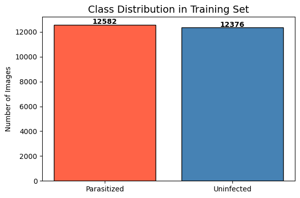

**Class balance check:**

- Parasitized: **12,582** images

- Uninfected: **12,376** images

- Status: dataset is **numerically imbalanced ⚠️**

```python
# ─────────────────────────────────────────────────────────────────────────────
# Cell purpose: visualise the per-class count from the previous cell as a bar
# chart, annotate each bar with its exact count, and print a one-line balance
# verdict.
# Inputs : counts, class_names (from earlier cell).
# Outputs: a matplotlib bar chart and a Markdown summary.
# ─────────────────────────────────────────────────────────────────────────────

# Visual class-balance check — the eye catches imbalance faster than a table.
fig, ax = plt.subplots(figsize=(6, 4))
# ↑ subplots(rows=1, cols=1) returns a (Figure, Axes) tuple. Figure = the
#   whole canvas; Axes = the actual plotting area.
# Red for Parasitized (warning/risk), blue for Uninfected (clear).
ax.bar(class_names, counts, color=['tomato', 'steelblue'], edgecolor='black')
ax.set_title('Class Distribution in Training Set', fontsize=14)
ax.set_ylabel('Number of Images')
# Annotate each bar with its exact count, placed 50 units above the top.
for i, v in enumerate(counts):
    ax.text(i, v + 50, str(v), ha='center', fontweight='bold')
    # ↑ ax.text(x, y, string, ha='center') places text horizontally centred
    #   at coordinate (x, y) in data units. `v + 50` lifts the label slightly
    #   above the bar top so it does not overlap the rectangle.
plt.tight_layout()
# ↑ tight_layout adjusts margins automatically so labels and titles do not
#   overflow or overlap.
plt.show()

# Programmatic balance check — the exact-equality test is strict; some datasets
# differ by a handful of images and still count as balanced for practical purposes.
balance_status = 'perfectly balanced ✅' if counts[0] == counts[1] else 'numerically imbalanced ⚠️'
# ↑ Python ternary expression: <value_if_true> if <condition> else <value_if_false>.
say(this=f"""
**Class balance check:**
- Parasitized: **{counts[0]:,}** images
- Uninfected:  **{counts[1]:,}** images
- Status: dataset is **{balance_status}**
""")
```

### ❓ Key Questions — Data Loading

> The next three sub-sections each ask one open-ended question about the dataset, then provide either a measurement or a proposed solution. Treat them as worked examples of *how to interrogate your data* before training a model.

> **Q: What is the image size distribution *before* resizing, and does our chosen IMG_SIZE avoid distortion of diagnostically important structures?**

> **Measured results (this dataset — 27,558 images):**

> **Most common native sizes (all images):** `130×130` (224 images), `124×127` (200), `130×127` (199), `124×124` (191), `127×124` (187)

> To reproduce this analysis and plot the size distribution:

> **Beginner glossary:**
> - **Interpolation artefacts**: visual patterns introduced by the resampling algorithm when a small image is enlarged. Common artefacts include blurring (bilinear) or block-like staircases (nearest neighbour).
> - **Downscaling**: shrinking an image. Generally safe — the algorithm averages real pixel data.
> - **Upscaling**: enlarging an image. Inherently lossy — extra pixels must be invented from neighbours, and a CNN can be fooled into learning these artefacts.

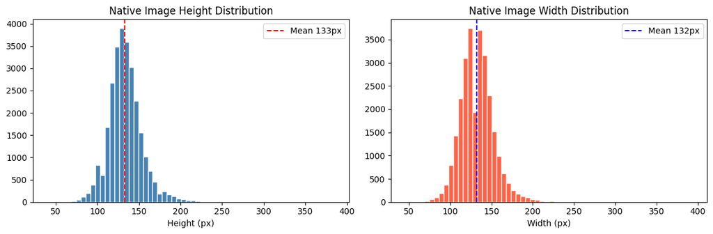

> **Native size summary (27,558 images):**

> | Stat | Height | Width | |------|--------|-------| | Min | `40` px | `46` px | | Max | `385` px | `394` px | | Mean | `133.0` px | `132.5` px | | Std | `20.6` px | `20.0` px |

> ⚠️ Images below 80px: `157` — consider filtering before training.

> **Native size summary (27,558 images):**

> | Stat | Height | Width | |------|--------|-------| | Min | `40` px | `46` px | | Max | `385` px | `394` px | | Mean | `133.0` px | `132.5` px | | Std | `20.6` px | `20.0` px |

> ⚠️ Images below 80px: `157` — consider filtering before training.

```python
# ─────────────────────────────────────────────────────────────────────────────
# Cell purpose: re-measure native image sizes and produce two histograms (one
# for height, one for width) plus a summary block-quote table. This visualises
# the size variability that motivated the dynamic IMG_SIZE choice above.
# Inputs : DATASET_ROOT.
# Outputs: histograms, a Markdown summary, globals hs (heights) and ws (widths).
# Gotcha : duplicates measure_mean_size logic — kept self-contained so this
#          cell can be lifted into a standalone analysis notebook.
# ─────────────────────────────────────────────────────────────────────────────

# PIL.Image, os, np, plt  →  already imported in Loading Libraries cell

def measure_sizes(at_path: str) -> tuple:
    heights, widths = [], []
    for dirpath, _, files in os.walk(at_path):
        for f in files:
            if f.lower().endswith(('.png', '.jpg', '.jpeg')):
                try:
                    w, h = Image.open(os.path.join(dirpath, f)).size
                    heights.append(h); widths.append(w)
                    # ↑ Semicolon lets us put two statements on one line.
                except:
                    pass
    return np.array(heights), np.array(widths)

hs, ws = measure_sizes(at_path=DATASET_ROOT)
# ↑ Tuple-unpacking: the function returns (heights, widths); we assign each
#   to its own name in a single line.

fig, axes = plt.subplots(1, 2, figsize=(12, 4))
# ↑ A 1-row, 2-column grid → `axes` is a length-2 array of Axes objects.
axes[0].hist(hs, bins=60, color='steelblue', edgecolor='white')
# ↑ hist() draws a histogram. `bins=60` means we group the values into 60
#   equally-sized buckets along the x-axis.
axes[0].axvline(hs.mean(), color='red', linestyle='--', label=f'Mean {hs.mean():.0f}px')
# ↑ axvline draws a vertical reference line at x = the mean height.
axes[0].set_title('Native Image Height Distribution')
axes[0].set_xlabel('Height (px)'); axes[0].legend()

axes[1].hist(ws, bins=60, color='tomato', edgecolor='white')
axes[1].axvline(ws.mean(), color='blue', linestyle='--', label=f'Mean {ws.mean():.0f}px')
axes[1].set_title('Native Image Width Distribution')
axes[1].set_xlabel('Width (px)'); axes[1].legend()

plt.tight_layout(); plt.show()

say(this=f"""
> **Native size summary ({len(hs):,} images):**
>
> | Stat | Height | Width |
> |------|--------|-------|
> | Min  | `{hs.min()}` px | `{ws.min()}` px |
> | Max  | `{hs.max()}` px | `{ws.max()}` px |
> | Mean | `{hs.mean():.1f}` px | `{ws.mean():.1f}` px |
> | Std  | `{hs.std():.1f}` px | `{ws.std():.1f}` px |
>
> ⚠️ Images below 80px: `{((hs < 80) | (ws < 80)).sum()}` — consider filtering before training.
> """f"""
> **Native size summary ({len(hs):,} images):**
>
> | Stat | Height | Width |
> |------|--------|-------|
> | Min  | `{hs.min()}` px | `{ws.min()}` px |
> | Max  | `{hs.max()}` px | `{ws.max()}` px |
> | Mean | `{hs.mean():.1f}` px | `{ws.mean():.1f}` px |
> | Std  | `{hs.std():.1f}` px | `{ws.std():.1f}` px |
>
> ⚠️ Images below 80px: `{((hs < 80) | (ws < 80)).sum()}` — consider filtering before training.
> """)
# ↑ `(hs < 80) | (ws < 80)` produces an element-wise boolean array (one True
#   per image where EITHER height OR width is below 80). `.sum()` counts the
#   Trues. `|` is NumPy's element-wise OR; do NOT use Python's `or` here, it
#   would crash on arrays.
```

> **Q: Are there duplicate or near-duplicate images between the train and test sets that could inflate reported accuracy?**

> Recommended solution: Compute a perceptual hash (pHash) for every image and flag any pair with a Hamming distance below a threshold. Even a small number of leaking duplicates can shift accuracy by 0.5–1% on a 2,600-image test set, making model comparisons unreliable.

> **Beginner glossary:**
> - **Data leakage**: any situation where information from the test set sneaks into the training set. Duplicates are the simplest form: if image X is in both splits, the model has effectively seen the test answer during training.
> - **Perceptual hash (pHash)**: a short fingerprint of an image that captures its visual content rather than its exact bytes. Two visually-similar images produce nearly identical hashes even if pixel values differ slightly (e.g. due to compression).
> - **Hamming distance**: the number of bit positions in which two equal-length bit strings differ. For two pHashes, a small Hamming distance ≈ near-duplicate.

```python
# ─────────────────────────────────────────────────────────────────────────────
# Cell purpose: compute perceptual hashes (pHash) for every image in train and
# test splits, then count exact-match collisions between the two sets. Any
# match indicates data leakage — the same (or visually identical) image
# appearing in both splits.
# Inputs : TRAIN_DIR, TEST_DIR.
# Outputs: globals train_hashes, test_hashes, leaks; a one-line summary.
# Gotcha : requires the `imagehash` package (pip install imagehash). The cell
#          will throw NameError if not installed — install before running.
# ─────────────────────────────────────────────────────────────────────────────

def hash_folder(at_path: str) -> dict:
    hashes = {}
    for root, _, files in os.walk(at_path):
        for f in files:
            path = os.path.join(root, f)
            try:
                h = str(imagehash.phash(Image.open(path)))
                # ↑ imagehash.phash returns a 64-bit fingerprint encoded as
                #   a hex string when wrapped in str(). Two visually-similar
                #   images produce hashes whose Hamming distance is small.
                hashes[path] = h
            except:
                pass
                # ↑ Skip any file that PIL cannot open (e.g. .DS_Store).
    return hashes

train_hashes = hash_folder(at_path=TRAIN_DIR)
test_hashes  = hash_folder(at_path=TEST_DIR)

train_hash_set = set(train_hashes.values())
# ↑ A set provides O(1) membership tests — much faster than scanning a list.
leaks = {p: h for p, h in test_hashes.items() if h in train_hash_set}
# ↑ Dictionary comprehension: build a new dict containing only the test
#   images whose hash already exists in the train set.
say(this=f"> **Duplicate check:** `{len(leaks)}` exact-match duplicates found between train and test sets.")
```

> **Duplicate check:** `0` exact-match duplicates found between train and test sets.

> **Q: Were all images collected from one lab and one microscope? How well does the model generalise to a different lab's staining protocol?**

> Recommended solution: This dataset originates from a single NIH study, so the model is at risk of learning lab-specific artefacts (e.g. a particular staining brand's colour cast) rather than truly generalising to Plasmodium morphology. The best mitigation is to evaluate on an external dataset from a different institution. A cheaper proxy is to apply aggressive colour-jitter augmentation (`brightness_range`, `channel_shift_range`) during training and confirm that test accuracy does not drop — if it does, the model is relying on colour intensity rather than shape.

> **Beginner glossary:**
> - **Domain shift**: when train and deployment data come from different distributions (e.g. different microscopes, lighting, stains). A model that memorises domain-specific quirks fails on a new domain.
> - **Colour cast**: an overall tint introduced by a particular dye batch, lighting source, or camera white-balance. Two labs imaging the same cell can produce subtly different colours.
> - **Colour-jitter augmentation**: random perturbations of brightness, contrast, saturation, hue at training time, forcing the model to rely on shape rather than absolute colour.